# 1.3 Data Visualisation

15 April 2019

## Data Visualisation

### Using the Package `ggplot2`

## The package `ggplot2`

`R` has numerous plotting functions in the base package `graphics`

```r
?plot
?boxplot
?hist
```

**Go to the `Examples` at the bottom of each help page and copy a few lines**

## The package `ggplot2`

- `ggplot2` gives much more flexibility and power
  - Is part of the core `tidyverse`
- Has unique syntax and approach
  - Based on [The Grammar of Graphics](https://www.springer.com/gp/book/9780387245447)
- We add layers of plotting information like geometry, colours, themes etc

## The package `ggplot2`: aesthetics

The main function is `ggplot()`

- In this first stage we set the plotting aesthetics using `aes()`
- Defines what is plotted on which axis, what defines the colour/shape etc.

```r
ggplot(transport, aes(x = weight, y = height))
```

No data will be plotted. We get the plot area only…

## The package `ggplot2`: geometry

- After defining the plot aesthetics, we:
  - Tell R that "more is to come" by adding a `+` symbol at the end of the line
  - Add the geometry using various `geom_...()` functions

```r
ggplot(transport, aes(x = weight, y = height)) +
  geom_point()
```

## The package `ggplot2`: geometry

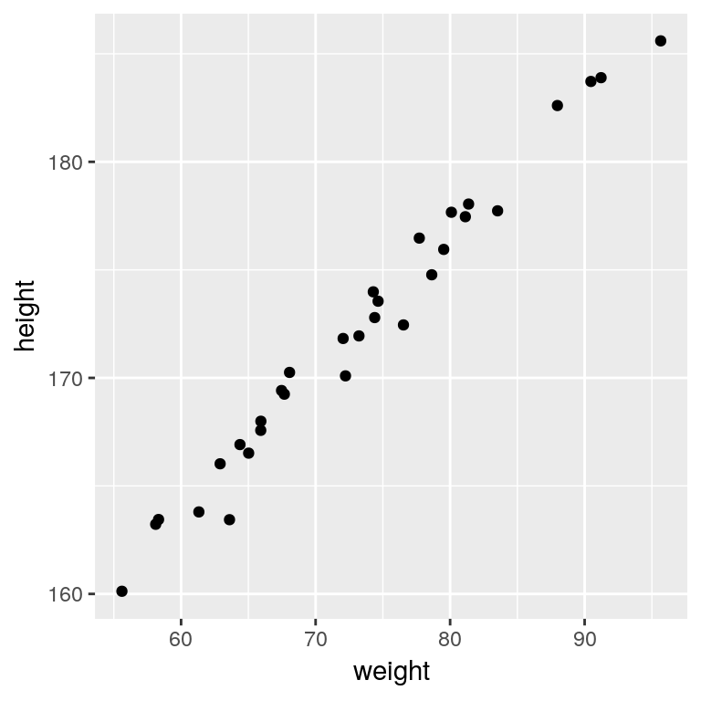

## The package `ggplot2`: aesthetics

There are numerous aesthetics available for `geom_point()`

```r
?geom_point
```

```r
ggplot(transport, aes(x = weight, y = height, colour = method)) +
  geom_point()
```

```r
ggplot(transport, aes(x = weight, y = height,
                      colour = method, shape = gender)) +
  geom_point()
```

## The package `ggplot2`: aesthetics

We can put the general aesthetics in `ggplot()`, with the `geom_point()` specific ones in that line

```r
ggplot(transport, aes(x = weight, y = height)) +
  geom_point(aes(colour = method, shape = gender))
```

- aesthetics set in `ggplot()` are passed to all geoms

## The package `ggplot2`: aesthetics

Aesthetics set outside of `aes()` are general across all points

```r
ggplot(transport, aes(x = weight, y = height)) +
  geom_point(aes(colour = method, shape = gender), size = 4)
```

## The package `ggplot2`: adding multiple geoms

```r
ggplot(transport, aes(x = weight, y = height)) +
  geom_point(aes(colour = method, shape = gender)) +
  geom_smooth()
```

This defaults to a `loess` fit

```r
ggplot(transport, aes(x = weight, y = height)) +
  geom_point(aes(colour = method, shape = gender)) +
  geom_smooth(method = "lm", formula = y~x, se = FALSE)
```

## The package `ggplot2`: labels

Point labels can be added using `geom_text()`

```r
ggplot(transport, aes(x = weight, y = height)) +
  geom_point(aes(colour = method, shape = gender)) +
  geom_smooth(method = "lm", formula = y~x, se = FALSE) +
  geom_text(aes(label= name)) +
  labs(x = "Weight (kg)", y = "Height (cm)",
       shape = "Gender", colour = "Transport")
```

## The package `ggplot2`: labels

They tend to be clumsy so

```r
library(ggrepel)
ggplot(transport, aes(x = weight, y = height)) +
  geom_point(aes(colour = method, shape = gender)) +
  geom_smooth(method = "lm", formula = y~x, se = FALSE) +
  geom_text_repel(aes(label= name)) +
  labs(x = "Weight (kg)", y = "Height (cm)",
       shape = "Gender", colour = "Transport")
```

## The package `ggplot2`: labels

Axis and legend labels can be added using `labs()`

```r
ggplot(transport, aes(x = weight, y = height)) +
  geom_point(aes(colour = method, shape = gender)) +
  geom_smooth(method = "lm", formula = y~x, se = FALSE) +
  geom_text_repel(aes(label= name)) +
  labs(x = "Weight (kg)", y = "Height (cm)",
       shape = "Gender", colour = "Transport")
```

## The package `ggplot2`: facets

(This is my favourite feature)

```r
ggplot(transport, aes(x = weight, y = height)) +
  geom_point(aes(colour = method, shape = gender)) +
  geom_smooth(method = "lm", formula = y~x, se = FALSE) +
  geom_text_repel(aes(label= name)) +
  labs(x = "Weight (kg)", y = "Height (cm)",
       shape = "Gender", colour = "Transport") +
  facet_wrap(~gender)
```

## The package `ggplot2`: Different geoms

Enter `geom_` in the Console followed by the `tab` key

```r
ggplot(transport, aes(x = height, fill = gender)) +
  geom_density(alpha = 0.5)
```

```r
ggplot(transport, aes(x = gender, y =height, fill = gender)) +
  geom_boxplot()
```

## The package `ggplot2`: `geom_bar()`

We can summarise our data before plotting

```r
transport %>%
  filter(!is.na(height)) %>%
  group_by(method, gender) %>%
  summarise(mn_height = mean(height), sd_height = sd(height)) %>%
  ggplot(aes(x = method, y = mn_height, fill = method)) +
  geom_bar(stat = "identity") +
  facet_wrap(~gender) +
  guides(fill = FALSE)
```

NB: `geom_bar()` requires `stat = "identity"`

## The package `ggplot2`: `geom_errorbar()`

```r
transport %>%
  filter(!is.na(height)) %>%
  group_by(method, gender) %>%
  summarise(mn_height = mean(height), sd_height = sd(height)) %>%
  ggplot(aes(x = method, y = mn_height, fill = method)) +
  geom_bar(stat = "identity") +
  geom_errorbar(aes(ymin = mn_height - sd_height,
                    ymax = mn_height + sd_height),
                width = 0.6)+
  facet_wrap(~gender) +
  guides(fill =FALSE)
```

## Making pie charts

These are not intuitive so here's how:

```r
transport %>%
  filter(!is.na(height)) %>%
  group_by(method) %>%
  summarise(n = n()) %>%
  ggplot(aes(x = 1, y = n, fill = method)) +
  geom_bar(stat = "identity", colour = "black") +
  coord_polar("y") +
  theme_void()
```

## The package `ggplot2`: facets

**How could we get histograms for both `weight` and `height` using facets?**

- The geom to use is `geom_histogram()`

## The package `ggplot2`: facets

**How could we get histograms for both `weight` and `height` using facets?**

```r
transport %>%
  gather(key = "measurement", value = "value",
         ends_with("ght")) %>%
  ggplot(aes(x = value, fill = measurement)) +
  geom_histogram(bins = 10, colour = "black") +
  facet_wrap(~measurement, scales = "free_x") +
  guides(fill = FALSE)
```

## The package `ggplot2`: facets

```r
transport %>%
  gather(key = "measurement", value = "value",
         ends_with("ght")) %>%
  ggplot(aes(x = gender, y = value, fill = gender)) +
  geom_boxplot() +
  facet_wrap(~measurement, scales = "free_y")
```

[Home](http://uofabioinformaticshub.github.io/Intro_R_FIB_2019/)